# Fire Service Survey: Exploration and insights

2/3/2017

## A note on this presentation

- This presentation was constructed using Rstudio's ioslides output from RMarkdown
- To view in presenter mode: add '?presentme=true' to the URL and be sure to allow pop-ups
- To view presenter notes, hit 'p' (sometimes this doesn't work properly, presenter mode is a more reliable way to see speaker notes)

## The Survey

- Fire Service Survey
- 5458 Records (respondents)
- Year unknown, post 2011 (per Q5)

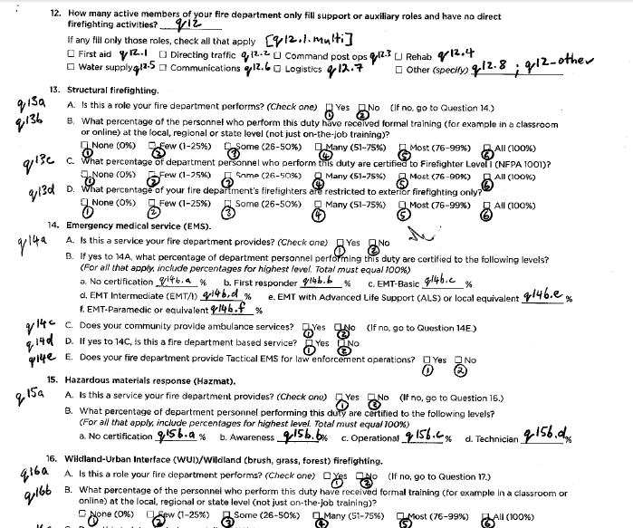

## Suggestions for Improvement to survey

- Migrate to electronic survey platform
- Questions prompting numeric responses unnecessarily broken out into ordinals
- Some questions poorly binned, resulting in skipped ranges and requiring "other" category
- Inconsistent binning choice across similar questions
- Inconsistent null representation
- Numbers as text (comma separated)

## FINDINGS

- Staffing levels (paid) are stable for most departments, but have changed significantly for others
- Women have stronger representation in volunteer departments
- The apparatus fleet is aging

## Staffing levels

52% of departments have no full-time paid personnel. Of those that have paid personnel, relative to 2011:

- 18% experienced a staffing decline
- 25% experienced a staffing increase
- 57% experienced no net change to staffing

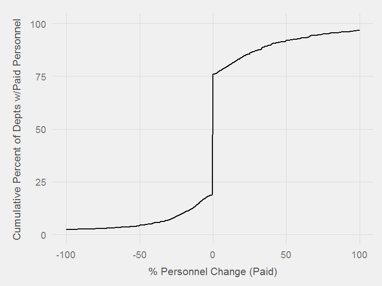

## Representation of Women

- Controlling for department size, women have higher representation in volunteer departments
- 21% of volunteer departments had at least 14% female staff, whereas only 1% of paid departments did.

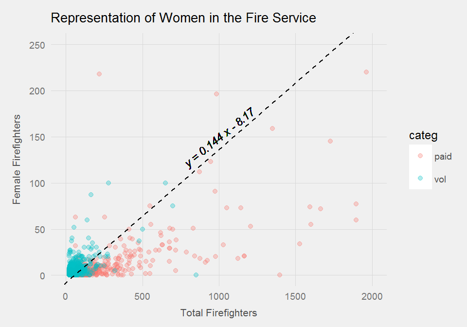

## Aging Fleet

- > 46% of stations are running apparatus that is 15+ years old

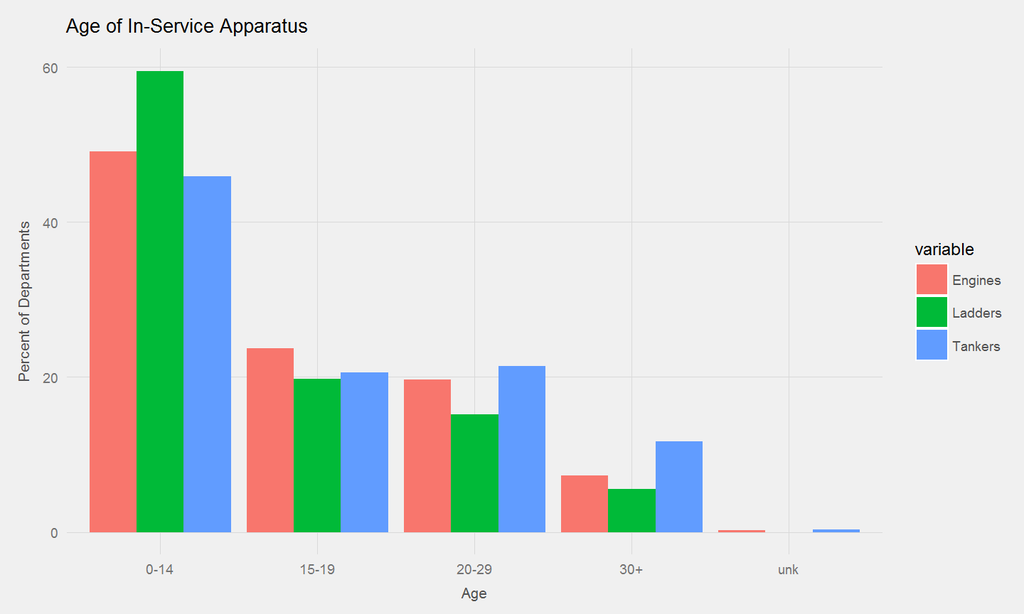